# WERN warehouse analysis

2023-07-18

## Overview

Updates to previous analysis:

- Changed the race categories to White/Black/Hispanic/Other
- Combined the size categories 1 to 9, 10 to 49, and 50 to 99 into category, 1 to 99
  - It is possible that 50 to 99 is really a different category than than the other two, but I’m not sure it it’s odd to separate it from the others
- Classified any warehouse that served customers at home as B2C even if it also served other businesses
  - Not sure if this was right choice…
- Added the following controls:
  - Permanent employment status
  - Union representation

There are a few things to keep in mind:

- Sample:
  - Hourly warehouse workers
  - I dropped those who report identifying as non-binary, as there were only a couple in the warehouse sample and this made it difficult to perform an intersectional analysis
- Method:
  - Simple OLS with standard errors that account for survey weights
- Significance levels are likely to change as we add or remove controls and toss out certain observations
- Because these models contain multiple dummy variables and interactions, proceed with caution when interpreting the coefficient estimates. It is usually much more straightforward to look at a visual, which is why I included some graphs. Let me know if you want to see other particular visuals.
- The reference levels used in regression analyses are:
  - Race: White
  - Gender: Male
  - Warehouse type: B2B
  - Warehouse size: 100 to 499
- Earnings and tenure are treated here as continuous but are really binned variables. Hence, the values themselves aren’t very meaningful–the levels are.
- The wage measure has a lot of missingness, so for now I am using an annual earnings measure (which isn’t great)

Main takeaways:

[Old takeways:]

Questions to discuss/next steps:

- **Besides the main takeaways above, what other through lines, stylized facts, suprises, puzzles, etc. might we convey at AOM?**
- For which variables do we want to compare hourly and salaried workers? Is there any reason to keep them in sample and control for pay type?
- What are other possible control variables?
  - There are other demographic variables, like marital status, which we might debate whether to include.
- I want to create a warehouse-specific measure of a bad schedule that is more about long hours than instability per se.
- The “Don’t know” response option is creating a lot of problems. What should be do about it? Keep in? Drop observations with it? Impute?
- Look at the relationship between technology or building size in a) surveillance and b) work intensity

## Summary tables

|  | Male | Female |
| --- | --- | --- |
| White | 181 | 67 |
| Black | 51 | 22 |
| Hispanic | 40 | 16 |
| Other | 10 | 14 |

|  | 1 to 99 | 100 to 499 | 500 or more |
| --- | --- | --- | --- |
| B2B | 101 | 45 | 43 |
| B2C | 73 | 61 | 45 |
| Don’t Know | 9 | 5 | 2 |

## Multivariate analyses

### Job characteristics

#### Alienation

|  | Another piece of machinery |
| --- | --- |
| (Intercept) | 3.251*** |
|  | (0.409) |
| Race |  |
| Black | -0.359+ |
|  | (0.212) |
| Hispanic | -0.103 |
|  | (0.221) |
| Other | -0.300 |
|  | (0.411) |
| Gender |  |
| Female | -0.130 |
|  | (0.213) |
| Race x Gender |  |
| Black x Female | 1.137** |
|  | (0.358) |
| Hispanic x Female | 0.273 |
|  | (0.490) |
| Other x Female | 1.035+ |
|  | (0.541) |
| Age | 0.001 |
|  | (0.007) |
| PT | -0.276 |
|  | (0.175) |
| Tenure | -0.097+ |
|  | (0.056) |
| Earnings | 0.000 |
|  | (0.014) |
| Contingent status | 0.098 |
|  | (0.203) |
| Union representation |  |
| Yes | 0.194 |
|  | (0.174) |
| Unsure | -0.155 |
|  | (0.289) |
| Warehouse type |  |
| B2C | 0.193 |
|  | (0.145) |
| Not Sure | 0.055 |
|  | (0.248) |
| Warehouse size (# employees) |  |
| 1 to 99 | -0.261 |
|  | (0.188) |
| 500 or more | 0.013 |
|  | (0.202) |
| Don’t Know | -0.206 |
|  | (0.329) |
| AIC | 903.4 |
| BIC | 696.7 |

+ p < 0.1, * p < 0.05, ** p < 0.01, *** p < 0.001

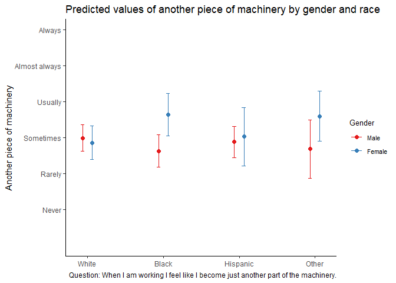

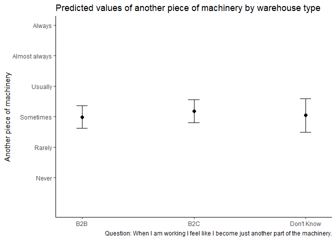

#### Effort

|  | Pace of work |
| --- | --- |
| (Intercept) | 3.736*** |
|  | (0.352) |
| Race |  |
| Black | 0.262 |
|  | (0.177) |
| Hispanic | 0.142 |
|  | (0.163) |
| Other | -0.410 |
|  | (0.382) |
| Gender |  |
| Female | 0.054 |
|  | (0.183) |
| Race x Gender |  |
| Black x Female | -0.135 |
|  | (0.314) |
| Hispanic x Female | -0.012 |
|  | (0.334) |
| Other x Female | 0.716 |
|  | (0.533) |
| Age | 0.000 |
|  | (0.006) |
| PT | 0.240+ |
|  | (0.144) |
| Tenure | -0.025 |
|  | (0.041) |
| Earnings | -0.006 |
|  | (0.011) |
| Contingent status | 0.020 |
|  | (0.214) |
| Union representation |  |
| Yes | -0.329* |
|  | (0.152) |
| Unsure | -0.167 |
|  | (0.250) |
| Warehouse type |  |
| B2C | 0.213+ |
|  | (0.120) |
| Not Sure | 0.201 |
|  | (0.289) |
| Warehouse size (# employees) |  |
| 1 to 99 | -0.330* |
|  | (0.142) |
| 500 or more | -0.254 |
|  | (0.167) |
| Don’t Know | -0.258 |
|  | (0.248) |
| AIC | 1149.9 |
| BIC | 507.6 |

+ p < 0.1, * p < 0.05, ** p < 0.01, *** p < 0.001

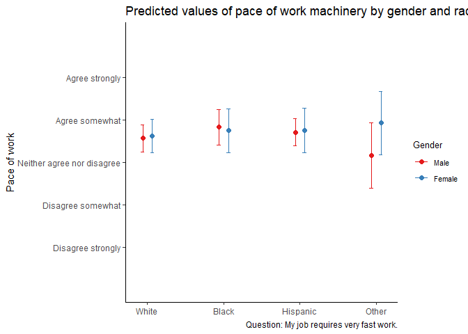

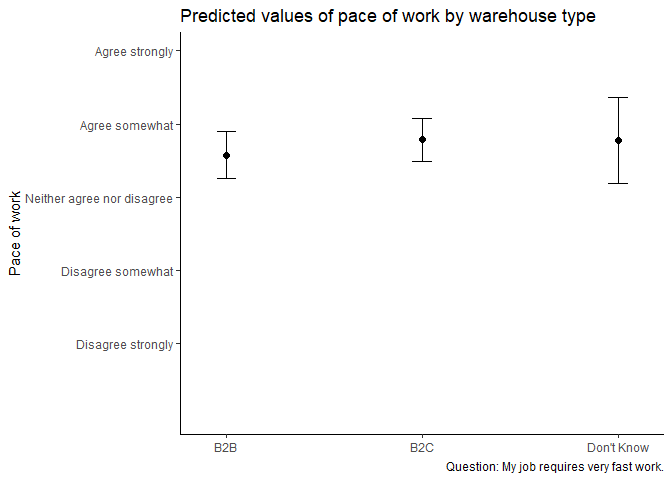

#### Pace monitoring

|  | Pace monitoring |
| --- | --- |
| (Intercept) | 4.823*** |
|  | (0.438) |
| Race |  |
| Black | 0.212 |
|  | (0.234) |
| Hispanic | 0.290 |
|  | (0.272) |
| Other | -0.803* |
|  | (0.353) |
| Gender |  |
| Female | 0.123 |
|  | (0.220) |
| Race x Gender |  |
| Black x Female | 0.158 |
|  | (0.366) |
| Hispanic x Female | -0.391 |
|  | (0.440) |
| Other x Female | 1.504** |
|  | (0.476) |
| Age | -0.004 |
|  | (0.007) |
| PT | 0.090 |
|  | (0.184) |
| Tenure | -0.195*** |
|  | (0.059) |
| Earnings | -0.027+ |
|  | (0.015) |
| Contingent status | -0.008 |
|  | (0.308) |
| Union representation |  |
| Yes | 0.026 |
|  | (0.203) |
| Unsure | -0.359 |
|  | (0.258) |
| Warehouse type |  |
| B2C | 0.519** |
|  | (0.159) |
| Not Sure | -0.336 |
|  | (0.476) |
| Warehouse size (# employees) |  |
| 1 to 99 | -0.617*** |
|  | (0.179) |
| 500 or more | -0.073 |
|  | (0.206) |
| Don’t Know | 0.404 |
|  | (0.487) |
| AIC | 815.9 |
| BIC | 791.3 |

+ p < 0.1, * p < 0.05, ** p < 0.01, *** p < 0.001

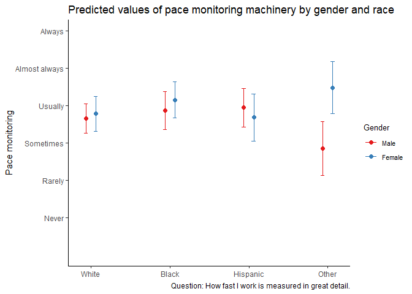

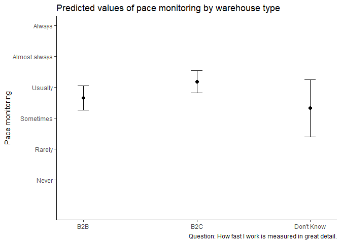

#### Monitoring intensity

|  | Monitoring intensity |
| --- | --- |
| (Intercept) | 4.421*** |
|  | (0.562) |
| Race |  |
| Black | -0.163 |
|  | (0.254) |
| Hispanic | -0.336 |
|  | (0.287) |
| Other | -0.859+ |
|  | (0.503) |
| Gender |  |
| Female | 0.180 |
|  | (0.261) |
| Race x Gender |  |
| Black x Female | 0.458 |
|  | (0.507) |
| Hispanic x Female | -0.016 |
|  | (0.585) |
| Other x Female | 1.951** |
|  | (0.633) |
| Age | -0.007 |
|  | (0.009) |
| PT | 0.215 |
|  | (0.216) |
| Tenure | -0.093 |
|  | (0.078) |
| Earnings | -0.028+ |
|  | (0.017) |
| Contingent status | -0.076 |
|  | (0.279) |
| Union representation |  |
| Yes | -0.032 |
|  | (0.228) |
| Unsure | 0.023 |
|  | (0.370) |
| Warehouse type |  |
| B2C | 0.250 |
|  | (0.191) |
| Not Sure | -1.418*** |
|  | (0.329) |
| Warehouse size (# employees) |  |
| 1 to 99 | -0.416+ |
|  | (0.243) |
| 500 or more | 0.099 |
|  | (0.269) |
| Don’t Know | -0.266 |
|  | (0.407) |
| AIC | 636.5 |
| BIC | 1097.4 |

+ p < 0.1, * p < 0.05, ** p < 0.01, *** p < 0.001

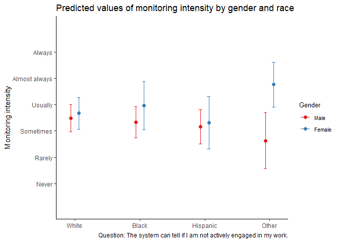

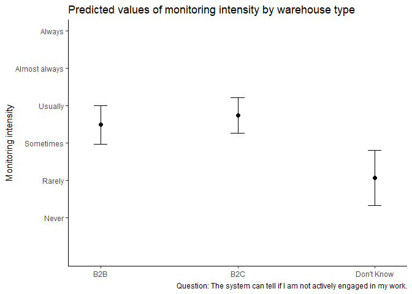

#### Positive surveillance

|  | Positive surveillance |
| --- | --- |
| (Intercept) | 3.172*** |
|  | (0.436) |
| Race |  |
| Black | 0.158 |
|  | (0.265) |
| Hispanic | 0.474+ |
|  | (0.256) |
| Other | 0.393 |
|  | (0.360) |
| Gender |  |
| Female | 0.275 |
|  | (0.192) |
| Race x Gender |  |
| Black x Female | -0.300 |
|  | (0.402) |
| Hispanic x Female | -0.425 |
|  | (0.433) |
| Other x Female | -0.080 |
|  | (0.427) |
| Age | -0.009 |
|  | (0.007) |
| PT | 0.573*** |
|  | (0.171) |
| Tenure | -0.015 |
|  | (0.064) |
| Earnings | 0.016 |
|  | (0.014) |
| Contingent status | 0.182 |
|  | (0.245) |
| Union representation |  |
| Yes | 0.126 |
|  | (0.227) |
| Unsure | -0.255 |
|  | (0.222) |
| Warehouse type |  |
| B2C | -0.047 |
|  | (0.162) |
| Not Sure | -0.251 |
|  | (0.303) |
| Warehouse size (# employees) |  |
| 1 to 99 | 0.099 |
|  | (0.189) |
| 500 or more | 0.106 |
|  | (0.199) |
| Don’t Know | 0.558 |
|  | (0.360) |
| AIC | 723.0 |
| BIC | 341.0 |

+ p < 0.1, * p < 0.05, ** p < 0.01, *** p < 0.001

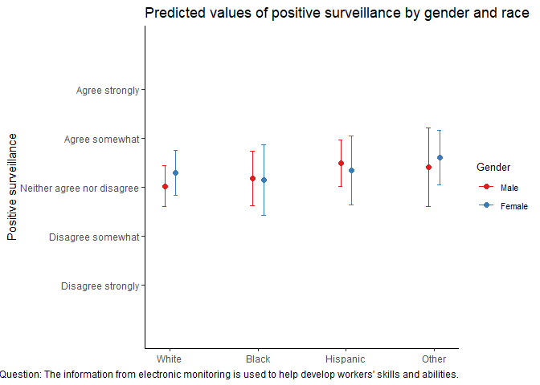

[figure not shown]

#### Negative surveillance

|  | Negative surveillance |
| --- | --- |
| (Intercept) | 3.068*** |
|  | (0.407) |
| Race |  |
| Black | -0.387 |
|  | (0.277) |
| Hispanic | 0.149 |
|  | (0.223) |
| Other | -1.037+ |
|  | (0.614) |
| Gender |  |
| Female | -0.097 |
|  | (0.223) |
| Race x Gender |  |
| Black x Female | 1.267** |
|  | (0.391) |
| Hispanic x Female | 0.457 |
|  | (0.370) |
| Other x Female | 1.251 |
|  | (0.791) |
| Age | 0.005 |
|  | (0.008) |
| PT | 0.423** |
|  | (0.161) |
| Tenure | -0.022 |
|  | (0.062) |
| Earnings | 0.023 |
|  | (0.015) |
| Contingent status | -0.352 |
|  | (0.313) |
| Union representation |  |
| Yes | 0.011 |
|  | (0.210) |
| Unsure | -0.156 |
|  | (0.300) |
| Warehouse type |  |
| B2C | -0.078 |
|  | (0.152) |
| Not Sure | -0.146 |
|  | (0.343) |
| Warehouse size (# employees) |  |
| 1 to 99 | 0.223 |
|  | (0.182) |
| 500 or more | -0.170 |
|  | (0.228) |
| Don’t Know | -0.123 |
|  | (0.380) |
| AIC | 699.7 |
| BIC | 349.1 |

+ p < 0.1, * p < 0.05, ** p < 0.01, *** p < 0.001

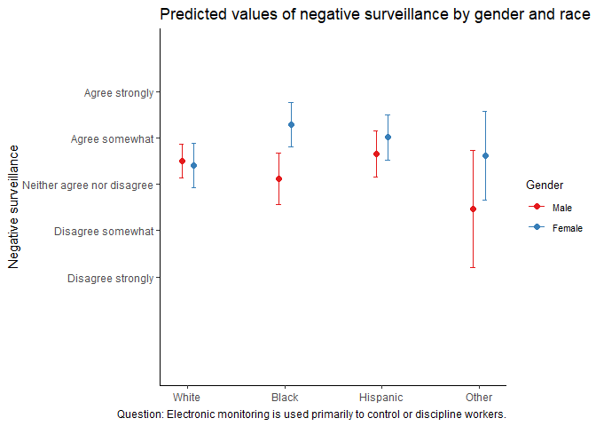

[figure not shown]

#### Schedule instability

|  | Schedule instability |
| --- | --- |
| (Intercept) | 1.660** |
|  | (0.590) |
| Race |  |
| Black | 0.239 |
|  | (0.328) |
| Hispanic | 0.510 |
|  | (0.368) |
| Other | 0.419 |
|  | (0.457) |
| Gender |  |
| Female | -0.356 |
|  | (0.282) |
| Race x Gender |  |
| Black x Female | 1.449* |
|  | (0.734) |
| Hispanic x Female | -0.168 |
|  | (0.747) |
| Other x Female | -0.931 |
|  | (0.604) |
| Age | 0.008 |
|  | (0.011) |
| PT | 0.436 |
|  | (0.337) |
| Tenure | 0.101 |
|  | (0.087) |
| Earnings | -0.052* |
|  | (0.023) |
| Contingent status | 0.907+ |
|  | (0.530) |
| Union representation |  |
| Yes | -0.095 |
|  | (0.301) |
| Unsure | -0.672 |
|  | (0.510) |
| Warehouse type |  |
| B2C | 0.064 |
|  | (0.235) |
| Not Sure | 0.029 |
|  | (0.889) |
| Warehouse size (# employees) |  |
| 1 to 99 | -0.095 |
|  | (0.309) |
| 500 or more | -0.254 |
|  | (0.311) |
| Don’t Know | -0.332 |
|  | (0.643) |
| AIC | 469.1 |
| BIC | 1698.2 |
| F | 2.583 |

+ p < 0.1, * p < 0.05, ** p < 0.01, *** p < 0.001

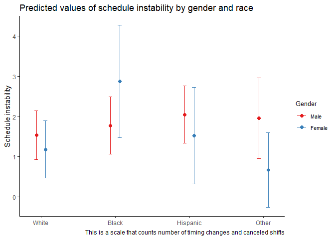

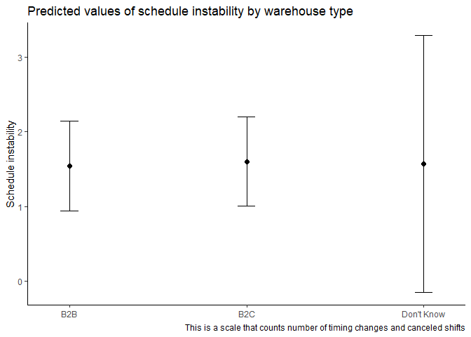

#### Schedule control

|  | Schedule control |
| --- | --- |
| (Intercept) | 2.732*** |
|  | (0.452) |
| Race |  |
| Black | 0.194 |
|  | (0.240) |
| Hispanic | 0.439+ |
|  | (0.241) |
| Other | 0.379 |
|  | (0.510) |
| Gender |  |
| Female | -0.120 |
|  | (0.235) |
| Race x Gender |  |
| Black x Female | -0.028 |
|  | (0.414) |
| Hispanic x Female | -0.813+ |
|  | (0.429) |
| Other x Female | 0.597 |
|  | (0.577) |
| Age | -0.004 |
|  | (0.007) |
| PT | 0.186 |
|  | (0.185) |
| Tenure | -0.090 |
|  | (0.060) |
| Earnings | 0.025 |
|  | (0.015) |
| Contingent status | 0.517* |
|  | (0.229) |
| Union representation |  |
| Yes | 0.084 |
|  | (0.197) |
| Unsure | 0.247 |
|  | (0.300) |
| Warehouse type |  |
| B2C | -0.078 |
|  | (0.155) |
| Not Sure | 0.090 |
|  | (0.465) |
| Warehouse size (# employees) |  |
| 1 to 99 | 0.142 |
|  | (0.191) |
| 500 or more | 0.291 |
|  | (0.210) |
| Don’t Know | -0.238 |
|  | (0.388) |
| AIC | 813.5 |
| BIC | 773.0 |
| F | 3.237 |

+ p < 0.1, * p < 0.05, ** p < 0.01, *** p < 0.001

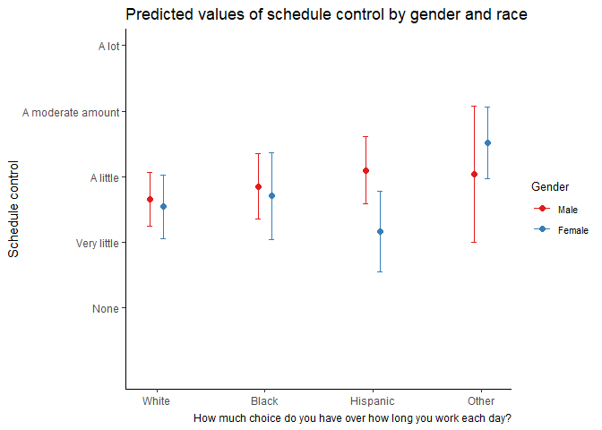

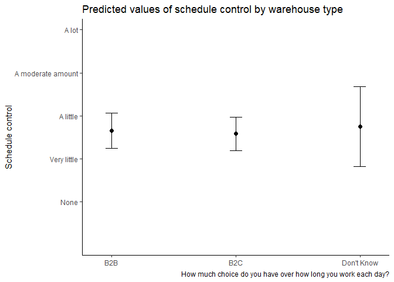

#### Schedule accomodations

|  | Schedule accomodation |
| --- | --- |
| (Intercept) | 3.105*** |
|  | (0.251) |
| Race |  |
| Black | 0.154 |
|  | (0.130) |
| Hispanic | 0.039 |
|  | (0.129) |
| Other | -0.093 |
|  | (0.251) |
| Gender |  |
| Female | 0.263* |
|  | (0.108) |
| Race x Gender |  |
| Black x Female | -0.646** |
|  | (0.235) |
| Hispanic x Female | -0.276 |
|  | (0.215) |
| Other x Female | -0.374 |
|  | (0.304) |
| Age | -0.003 |
|  | (0.004) |
| PT | -0.116 |
|  | (0.095) |
| Tenure | -0.008 |
|  | (0.030) |
| Earnings | 0.010 |
|  | (0.009) |
| Contingent status | 0.046 |
|  | (0.134) |
| Union representation |  |
| Yes | -0.076 |
|  | (0.097) |
| Unsure | -0.089 |
|  | (0.208) |
| Warehouse type |  |
| B2C | 0.081 |
|  | (0.087) |
| Not Sure | -0.107 |
|  | (0.241) |
| Warehouse size (# employees) |  |
| 1 to 99 | -0.101 |
|  | (0.102) |
| 500 or more | -0.099 |
|  | (0.113) |
| Don’t Know | -0.077 |
|  | (0.258) |
| AIC | 1735.2 |
| BIC | 316.8 |
| F | 1.446 |

+ p < 0.1, * p < 0.05, ** p < 0.01, *** p < 0.001

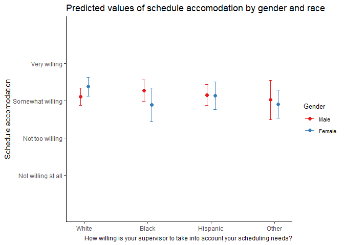

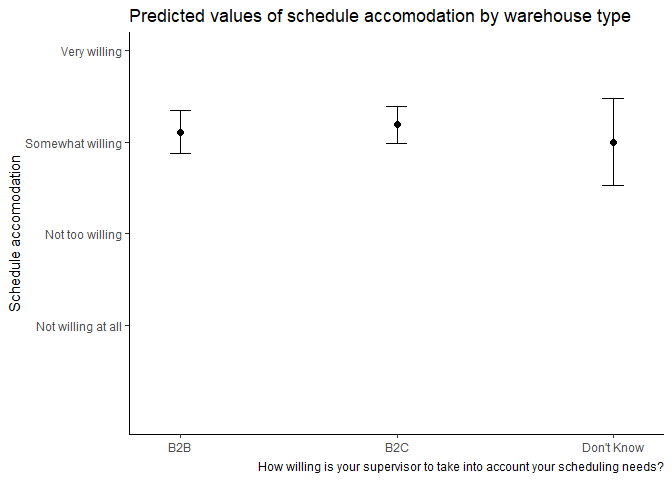

#### Earnings prediction

|  | Annual earnings |
| --- | --- |
| (Intercept) | 14.684*** |
|  | (1.355) |
| Race |  |
| Black | -1.973* |
|  | (0.851) |
| Hispanic | -1.629+ |
|  | (0.906) |
| Other | -1.447 |
|  | (2.484) |
| Gender |  |
| Female | -2.493** |
|  | (0.854) |
| Race x Gender |  |
| Black x Female | 1.749 |
|  | (1.603) |
| Hispanic x Female | 2.428 |
|  | (1.657) |
| Other x Female | 0.566 |
|  | (2.754) |
| Age | 0.039 |
|  | (0.028) |
| PT | -3.068*** |
|  | (0.713) |
| Tenure | 0.341 |
|  | (0.215) |
| Union representation |  |
| Yes | -0.927 |
|  | (0.948) |
| Unsure | -4.080** |
|  | (1.461) |
| Warehouse type |  |
| B2C | -0.361 |
|  | (0.647) |
| Not Sure | -1.445 |
|  | (1.490) |
| Warehouse size (# employees) |  |
| 1 to 99 | -0.621 |
|  | (0.751) |
| 500 or more | 1.491+ |
|  | (0.851) |
| Don’t Know | -0.471 |
|  | (1.593) |
| AIC | 144.4 |
| BIC | 10322.7 |

+ p < 0.1, * p < 0.05, ** p < 0.01, *** p < 0.001

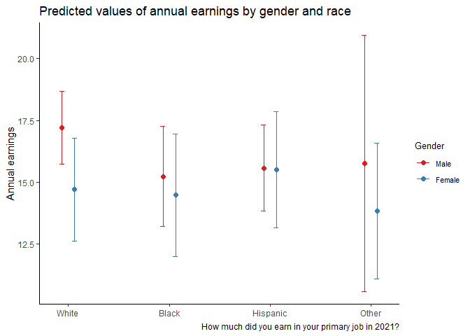

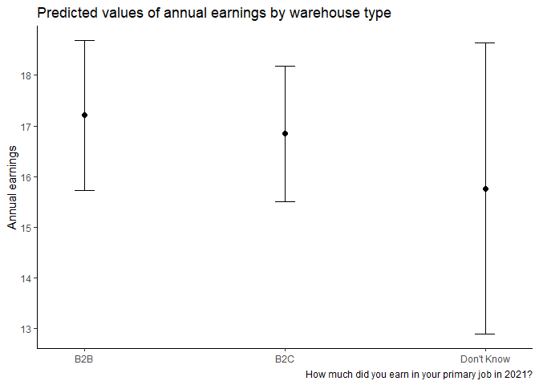

### Job quality

#### Production anxiety

|  | Production anxiety |
| --- | --- |
| (Intercept) | 3.366*** |
|  | (0.522) |
| Race |  |
| Black | -0.423+ |
|  | (0.224) |
| Hispanic | 0.267 |
|  | (0.304) |
| Other | -1.035* |
|  | (0.449) |
| Gender |  |
| Female | -0.066 |
|  | (0.228) |
| Race x Gender |  |
| Black x Female | 0.612 |
|  | (0.385) |
| Hispanic x Female | 0.727 |
|  | (0.619) |
| Other x Female | 1.188+ |
|  | (0.645) |
| Age | -0.016* |
|  | (0.008) |
| PT | -0.244 |
|  | (0.212) |
| Tenure | 0.099 |
|  | (0.068) |
| Earnings | -0.032+ |
|  | (0.018) |
| Contingent status | 0.751* |
|  | (0.291) |
| Union representation |  |
| Yes | 0.104 |
|  | (0.225) |
| Unsure | 0.041 |
|  | (0.336) |
| Warehouse type |  |
| B2C | 0.349+ |
|  | (0.189) |
| Not Sure | -0.675* |
|  | (0.282) |
| Warehouse size (# employees) |  |
| 1 to 99 | 0.130 |
|  | (0.215) |
| 500 or more | 0.612* |
|  | (0.255) |
| Don’t Know | 0.214 |
|  | (0.556) |
| AIC | 699.2 |
| BIC | 846.5 |

+ p < 0.1, * p < 0.05, ** p < 0.01, *** p < 0.001

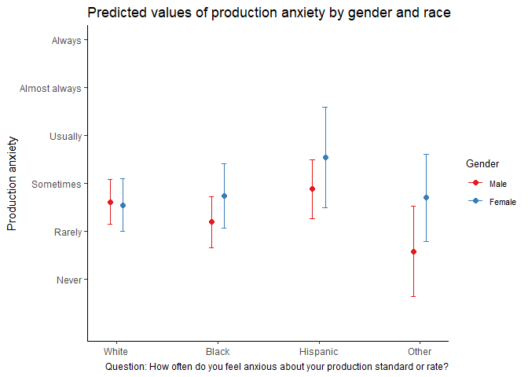

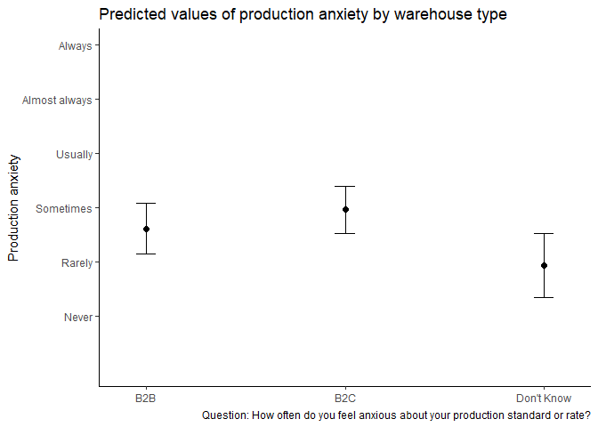

#### Bathroom break

|  | Bathroom break |
| --- | --- |
| (Intercept) | 3.574*** |
|  | (0.547) |
| Race |  |
| Black | 0.158 |
|  | (0.260) |
| Hispanic | 0.421 |
|  | (0.299) |
| Other | -0.018 |
|  | (0.405) |
| Gender |  |
| Female | -0.104 |
|  | (0.225) |
| Race x Gender |  |
| Black x Female | 0.526 |
|  | (0.406) |
| Hispanic x Female | 0.744 |
|  | (0.693) |
| Other x Female | 0.447 |
|  | (0.524) |
| Age | -0.015+ |
|  | (0.008) |
| PT | -0.180 |
|  | (0.207) |
| Tenure | 0.034 |
|  | (0.070) |
| Earnings | -0.051** |
|  | (0.018) |
| Contingent status | 0.637* |
|  | (0.312) |
| Union representation |  |
| Yes | 0.102 |
|  | (0.241) |
| Unsure | -0.344 |
|  | (0.363) |
| Warehouse type |  |
| B2C | 0.364* |
|  | (0.185) |
| Not Sure | -0.753 |
|  | (0.757) |
| Warehouse size (# employees) |  |
| 1 to 99 | 0.131 |
|  | (0.213) |
| 500 or more | 0.433+ |
|  | (0.242) |
| Don’t Know | 0.709 |
|  | (0.522) |
| AIC | 711.2 |
| BIC | 838.3 |

+ p < 0.1, * p < 0.05, ** p < 0.01, *** p < 0.001

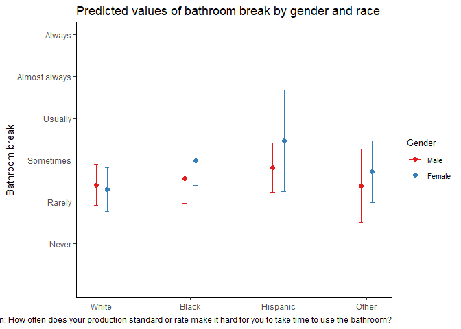

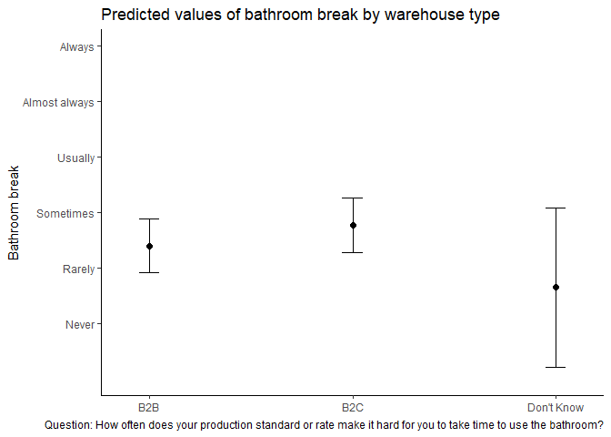

#### Safety priority

|  | Safety priority |
| --- | --- |
| (Intercept) | 3.481*** |
|  | (0.367) |
| Race |  |
| Black | 0.136 |
|  | (0.160) |
| Hispanic | -0.320 |
|  | (0.215) |
| Other | -0.096 |
|  | (0.415) |
| Gender |  |
| Female | -0.023 |
|  | (0.169) |
| Race x Gender |  |
| Black x Female | -0.394 |
|  | (0.344) |
| Hispanic x Female | 0.146 |
|  | (0.343) |
| Other x Female | -0.231 |
|  | (0.564) |
| Age | 0.019*** |
|  | (0.005) |
| PT | 0.077 |
|  | (0.151) |
| Tenure | -0.057 |
|  | (0.045) |
| Earnings | 0.016 |
|  | (0.013) |
| Contingent status | -0.072 |
|  | (0.254) |
| Union representation |  |
| Yes | -0.273 |
|  | (0.183) |
| Unsure | 0.412 |
|  | (0.253) |
| Warehouse type |  |
| B2C | -0.205 |
|  | (0.134) |
| Not Sure | 0.212 |
|  | (0.289) |
| Warehouse size (# employees) |  |
| 1 to 99 | -0.126 |
|  | (0.152) |
| 500 or more | -0.213 |
|  | (0.173) |
| Don’t Know | -0.215 |
|  | (0.340) |
| AIC | 1090.7 |
| BIC | 547.1 |

+ p < 0.1, * p < 0.05, ** p < 0.01, *** p < 0.001

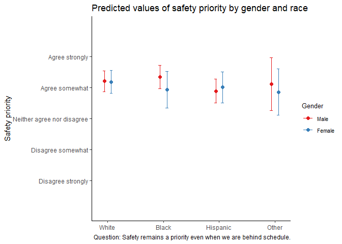

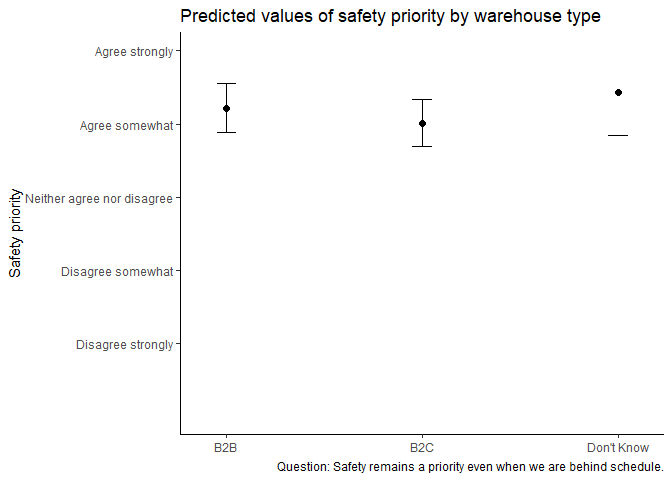

#### Safety risk

|  | Safety risk |
| --- | --- |
| (Intercept) | 3.562*** |
|  | (0.386) |
| Race |  |
| Black | -0.026 |
|  | (0.176) |
| Hispanic | -0.451* |
|  | (0.214) |
| Other | 0.315 |
|  | (0.317) |
| Gender |  |
| Female | -0.037 |
|  | (0.181) |
| Race x Gender |  |
| Black x Female | -0.422 |
|  | (0.348) |
| Hispanic x Female | 0.364 |
|  | (0.390) |
| Other x Female | -0.928 |
|  | (0.573) |
| Age | 0.009 |
|  | (0.006) |
| PT | 0.146 |
|  | (0.163) |
| Tenure | 0.036 |
|  | (0.051) |
| Earnings | 0.001 |
|  | (0.013) |
| Contingent status | -0.481+ |
|  | (0.269) |
| Union representation |  |
| Yes | -0.071 |
|  | (0.177) |
| Unsure | 0.182 |
|  | (0.251) |
| Warehouse type |  |
| B2C | -0.252+ |
|  | (0.138) |
| Not Sure | -0.271 |
|  | (0.249) |
| Warehouse size (# employees) |  |
| 1 to 99 | 0.140 |
|  | (0.167) |
| 500 or more | -0.136 |
|  | (0.181) |
| Don’t Know | 0.314 |
|  | (0.242) |
| AIC | 1025.7 |
| BIC | 593.7 |

+ p < 0.1, * p < 0.05, ** p < 0.01, *** p < 0.001

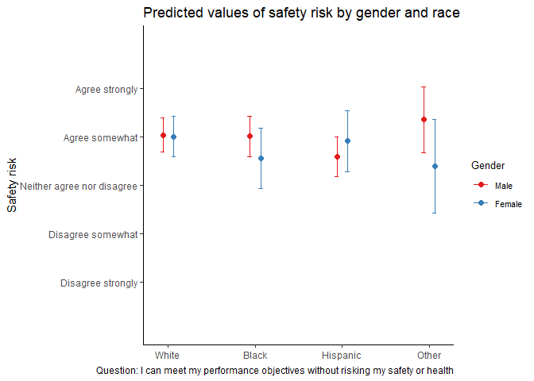

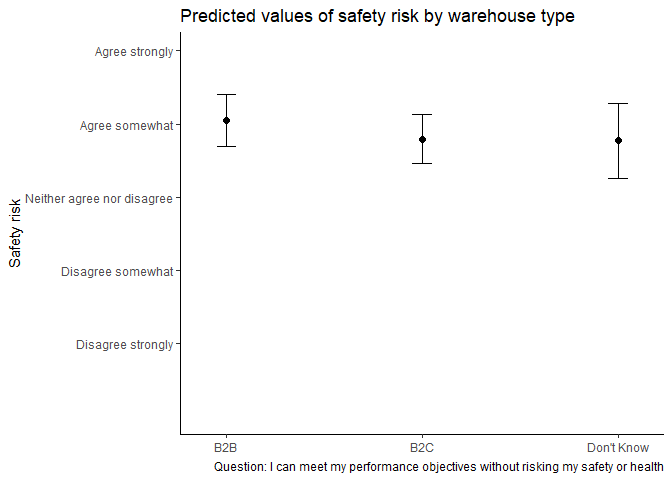

#### Stressful job

|  | Stressful job |
| --- | --- |
| (Intercept) | 2.151*** |
|  | (0.272) |
| Race |  |
| Black | -0.286* |
|  | (0.137) |
| Hispanic | -0.166 |
|  | (0.159) |
| Other | 0.163 |
|  | (0.260) |
| Gender |  |
| Female | -0.156 |
|  | (0.137) |
| Race x Gender |  |
| Black x Female | 0.649** |
|  | (0.230) |
| Hispanic x Female | 0.132 |
|  | (0.292) |
| Other x Female | 0.182 |
|  | (0.368) |
| Age | -0.001 |
|  | (0.005) |
| PT | -0.043 |
|  | (0.105) |
| Tenure | -0.014 |
|  | (0.037) |
| Earnings | -0.003 |
|  | (0.010) |
| Contingent status | 0.013 |
|  | (0.151) |
| Union representation |  |
| Yes | 0.042 |
|  | (0.126) |
| Unsure | 0.234 |
|  | (0.216) |
| Warehouse type |  |
| B2C | 0.050 |
|  | (0.100) |
| Not Sure | -0.169 |
|  | (0.205) |
| Warehouse size (# employees) |  |
| 1 to 99 | 0.025 |
|  | (0.116) |
| 500 or more | -0.043 |
|  | (0.136) |
| Don’t Know | -0.039 |
|  | (0.248) |
| AIC | 1488.5 |
| BIC | 377.2 |

+ p < 0.1, * p < 0.05, ** p < 0.01, *** p < 0.001

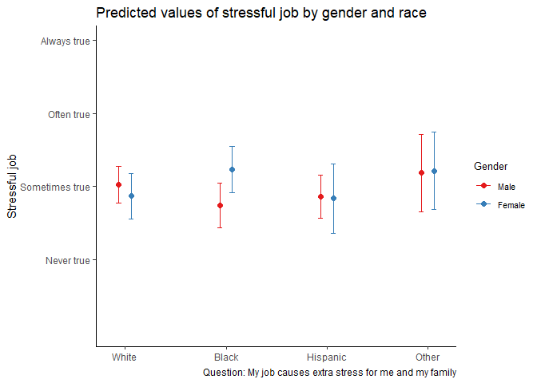

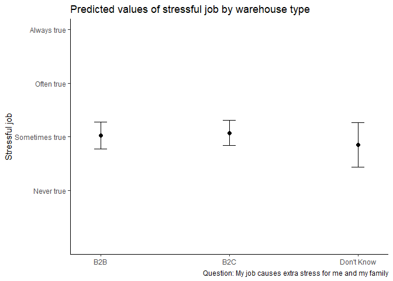